# Regresión lineal múltiple

Luis Fernando Apáez álvarez

17 de Septiembre de 2022

## Ejemplo Ancova: Parte II

Recordemos rápidamente que:

```r
# Cargamos los datos
CADdata <- read.table("cadmium.txt", header=TRUE, sep=" ", dec=".")

# Convertimos la variable group a tipo factor
CADdata$group <- factor(CADdata$group, levels=c(1, 2, 3), labels=c("High", "Low", "No") )

# Filtramos los datos por edad. Consideraremos a la
# persona mas joven del grupo de exposicion alta
CADdata <- CADdata[CADdata$age >= 39, ]
```

vemos un gráfico con los datos ya filtrados

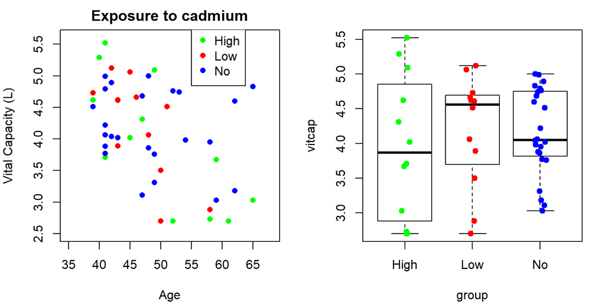

```r
par(mfrow=c(1,2)); par(mar=c(4,4,2,1.5))

plot(CADdata$age, CADdata$vitcap, col=c("green","red","blue")[CADdata$group], xlab = "Age",
     ylab = "Vital Capacity (L)", xlim=c(35,68), ylim=c(2.5,5.6),
     pch=c(16,16,16), main = "Exposure to cadmium")
legend(55,5.8, levels(CADdata$group),
       col=c("green","red","blue"), pch = c(16,16,16) )

boxplot(vitcap ~ group, data = CADdata, col = "white", outline=FALSE)
stripchart(vitcap ~ group, data = CADdata,
           method = "jitter",
           pch = 19,
           col = c("green","red","blue"),
           vertical = TRUE,
           add = TRUE)
```

Depués, buscaremos ajustar el modelo saturado (el que considera todas las variables), el cual nos brindará información para dirigirnos a obtener un mejor modelo. Modelo completo:

$$E(y;x)= \beta_0 + \beta_1\cdot age + \beta_2 \cdot Low + \beta_3 \cdot
No + \beta_4(age\cdot Low) + \beta_5(age\cdot No)$$
Ajustamos

```r
fit <- lm(vitcap ~ age * group, data = CADdata)
summary(fit)
```

```
##
## Call:
## lm(formula = vitcap ~ age * group, data = CADdata)
##
## Residuals:
##     Min      1Q  Median      3Q     Max
## -1.1017 -0.3456 -0.0324  0.5152  1.0770
##
## Coefficients:
##              Estimate Std. Error t value Pr(>|t|)
## (Intercept)    8.1834     1.0641    7.69  1.5e-09 ***
## age           -0.0851     0.0211   -4.04  0.00022 ***
## groupLow       1.2369     2.0332    0.61  0.54622
## groupNo       -3.3940     1.3446   -2.52  0.01547 *
## age:groupLow  -0.0273     0.0426   -0.64  0.52586
## age:groupNo    0.0722     0.0269    2.69  0.01031 *
## ---
## Signif. codes:  0 '***' 0.001 '**' 0.01 '*' 0.05 '.' 0.1 ' ' 1
##
## Residual standard error: 0.64 on 42 degrees of freedom
## Multiple R-squared:  0.394,  Adjusted R-squared:  0.321
## F-statistic: 5.45 on 5 and 42 DF,  p-value: 0.000592
```

donde tenemos las esperanzas

$$\begin{align*}
&E(Y;group=High, age)= \beta_0 + \beta_1\cdot age\\
&E(Y;group= Low, age)= \beta_0 + \beta_1 age +\beta_2 + \beta_4 age
= (\beta_0 + \beta_2) + (\beta_1 + \beta_4) age\\
&E(Y;group= No, age)= \beta_0 + \beta_1 age + \beta_3 + \beta_5
age = (\beta_0 + \beta_3) + (\beta_1 + \beta_5) age
\end{align*}$$

Este modelo considera tres diferentes rectas, una para cada grupo Se rechaza $H_0$ en la prueba asociada a la tabla ANOVA (p-value: 0.000592), entonces el modelo tiene sentido. Es decir, la edad o el nivel de exposición ayudan a modelar $E(Y)$.

Lo que debería seguir inmediatamente después de lo anterior es la verificación de supuestos, lo cual haremos más adelante.

### Continuación

Seguimos con prueba de igualdad de pendientes (coeficientes asociados a las interacciones). Si no se rechaza, podríamos optar por un modelo con igualdad de pendientes o rectas paralelas (facilita la interpretación), donde la prueba a realizar contrastar es:

$$H_0: \beta_4=0\ \ y \ \ \beta_5=0\ \ vs \ \ H_a: \beta_4\neq0 \ \ o\
\ \beta_5\neq0$$
para lo cual utilizaremos la librería multcomp

```r
library(multcomp)
K <- matrix(c(0,0,0,0,1,0,
              0,0,0,0,0,1), ncol=6, nrow=2, byrow=TRUE)
m <- c(0,0)
#                                  via la prueba F
summary(glht(fit, linfct=K, rhs=m), test=Ftest())
```

```
##
##   General Linear Hypotheses
##
## Linear Hypotheses:
##        Estimate
## 1 == 0  -0.0273
## 2 == 0   0.0722
##
## Global Test:
##      F DF1 DF2 Pr(>F)
## 1 5.27   2  42 0.0091
```

donde se rechaza $H_{0}$ (p-value: 0.0091). No se puede considerar el modelo con rectas paralelas. Procedemos a ver si las tres rectas tienen pendiente diferente (intentar reducir el modelo), es decir, es la prueba simultánea que sigue a la prueba lineal general.

Notar que aquí se incluyen las tres hipótesis individuales asociadas a

- H0_1: pendientes de High y Low iguales (b4=0)
- H0_2: pendientes de High y No iguales (b5=0)
- H0_3: pendientes de Low y No iguales (b4-b5=0)

Esta prueba sólo detecta las diferencias más evidentes, la lectura se debe hacer con cuidado considerando que esta prueba tiene más chance de cometer el error tipo II

```r
# ¿Todas las pendientes difieren?
K <- matrix(c(0,0,0,0,1,0,
              0,0,0,0,0,1,
              0,0,0,0,1,-1), ncol=6, nrow=3, byrow=TRUE)
m <- c(0,0,0)
#           via pruebas simultaneas
summary(glht(fit, linfct=K, rhs=m))
```

```
##
##   Simultaneous Tests for General Linear Hypotheses
##
## Fit: lm(formula = vitcap ~ age * group, data = CADdata)
##
## Linear Hypotheses:
##        Estimate Std. Error t value Pr(>|t|)
## 1 == 0  -0.0273     0.0426   -0.64    0.795
## 2 == 0   0.0722     0.0269    2.69    0.026 *
## 3 == 0  -0.0995     0.0406   -2.45    0.046 *
## ---
## Signif. codes:  0 '***' 0.001 '**' 0.01 '*' 0.05 '.' 0.1 ' ' 1
## (Adjusted p values reported -- single-step method)
```

De forma simultánea podemos identificar que se rechaza $H_0$ por dos diferencias:

1. Se rechaza $\beta_5=0$, pues $p-value < 0.026$. Hay evidencia sobre pendientes de High y No diferentes.
2. Se rechaza $\beta_4-\beta:5=0$, pues $p-value < 0.046$. Hay evidencia sobre pendientes de Low y No diferentes

Con esta prueba no se rechaza $\beta_4=0$, por lo que podríamos optar por considerar un modelo con $\beta_4=0$. Ajustemos el modelo reducido que sólo considera a (age*No), este nuevo modelo corresponde a

$$E(y;x)= \beta_0 + \beta_1 age + \beta_2 Low + \beta_3 No +
\beta_4(age\cdot No)$$
por lo cual realizamos el ajuste del modelo anterior como sigue

```r
fitred <- lm(vitcap ~ age + group + I(age*(group=="No")), data = CADdata)
summary(fitred)
```

```
##
## Call:
## lm(formula = vitcap ~ age + group + I(age * (group == "No")),
##     data = CADdata)
##
## Residuals:
##     Min      1Q  Median      3Q     Max
## -1.1738 -0.3758 -0.0677  0.5384  1.0720
##
## Coefficients:
##                          Estimate Std. Error t value Pr(>|t|)
## (Intercept)                8.5149     0.9230    9.22  9.4e-12 ***
## age                       -0.0918     0.0182   -5.05  8.7e-06 ***
## groupLow                  -0.0524     0.2647   -0.20   0.8439
## groupNo                   -3.7255     1.2323   -3.02   0.0042 **
## I(age * (group == "No"))   0.0789     0.0246    3.20   0.0026 **
## ---
## Signif. codes:  0 '***' 0.001 '**' 0.01 '*' 0.05 '.' 0.1 ' ' 1
##
## Residual standard error: 0.63 on 43 degrees of freedom
## Multiple R-squared:  0.388,  Adjusted R-squared:  0.331
## F-statistic: 6.81 on 4 and 43 DF,  p-value: 0.000245
```

donde tenemos las esperanzas:

$$\begin{align*}
&E(Y;group=High, age)= \beta_0 + \beta_1\cdot age\\
&E(Y;group= Low, age)= \beta_0 + \beta_1 age +\beta_2 = (\beta_0 +
\beta_2) + \beta_1+ age\\
&E(Y;group= No, age)= \beta_0 + \beta_1 age + \beta_3 + \beta_4
age = (\beta_0 + \beta_3) + (\beta_1 + \beta_4) age
\end{align*}$$

y donde se rechaza $H_0$ en la prueba asociada a la tabla ANOVA (p-value: 0.000245). Ahora podríamos proceder a reducir un poco más el modelo para tratar de facilitar la interpretación o bien a contestar las preguntas sobre los investigadores.

De la salida de fitred, se puede observar que una opción es considerar $\beta_2=0$.

El modelo reducido quedaría como

$$E(y;x)= \beta_0 + \beta_1 age + \beta_2 No + \beta_3(age\cdot No)$$

donde:

$$\begin{align*}
&E(Y;group=High, age)= \beta_0 + \beta_1 age\\
&E(Y;group= Low, age)= \beta_0 + \beta_1 age \\
&E(Y;group= No, age)= \beta_0 + \beta_1 age + \beta_2 + \beta_3
age = (\beta_0 + \beta_2) + (\beta_1 + \beta_3) age
\end{align*}$$

Con esto se tendrían rectas iguales para High y Low por otro lado, se tiene otra recta para No. Ajustamos otro modelo para el nuevo modelo reducido:

```r
fitred2 <- lm(vitcap ~ age + I(group=="No") + I(age*(group=="No")), data = CADdata)
summary(fitred2)
```

```
##
## Call:
## lm(formula = vitcap ~ age + I(group == "No") + I(age * (group ==
##     "No")), data = CADdata)
##
## Residuals:
##     Min      1Q  Median      3Q     Max
## -1.2015 -0.3863 -0.0677  0.5428  1.0975
##
## Coefficients:
##                          Estimate Std. Error t value Pr(>|t|)
## (Intercept)                8.4499     0.8534    9.90  9.1e-13 ***
## age                       -0.0910     0.0175   -5.19  5.2e-06 ***
## I(group == "No")TRUE      -3.6605     1.1748   -3.12   0.0032 **
## I(age * (group == "No"))   0.0781     0.0240    3.25   0.0022 **
## ---
## Signif. codes:  0 '***' 0.001 '**' 0.01 '*' 0.05 '.' 0.1 ' ' 1
##
## Residual standard error: 0.62 on 44 degrees of freedom
## Multiple R-squared:  0.387,  Adjusted R-squared:  0.345
## F-statistic: 9.27 on 3 and 44 DF,  p-value: 7.26e-05
```

Se rechaza $H_0$ en la prueba asociada a la tabla ANOVA ($p-value: 7.26e-05$). También se puede observar que no se podría reducir más el modelo.

Las rectas ajustadas son:

$$\begin{align*}
&\hat{E}(Y;group=High, age)=\hat{E}(Y;group=Low, age)= 8.4499
-0.0910 age\\
&\hat{E}(Y;group=No, age)= (8.4499-3.6605)+(-0.0910+0.0781) age
=4.789-0.0129 age
\end{align*}$$

Se puede observar que la pendiente de los expuestos a cadmio es mayor en valor absoluto y negativa con lo que podemos interpretar que la capacidad vital decrece más rápido en ese grupo comparado con los no expuesto.

Esto se puede observar más fácilmente en una gráfica

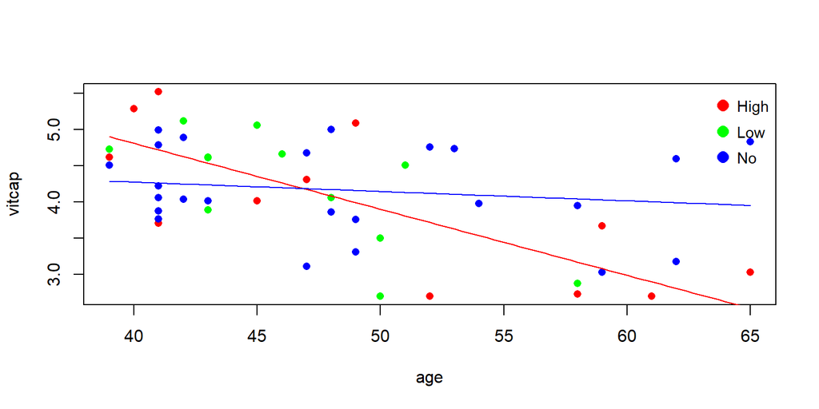

```r
# Modelo fitred2

# Definimos dos funciones apra graficar las rectas:
# * Recta para los que se expusieron altamente y bajamente
#   al cadmio
fitredHyL <- function(X2) {fitred2$coefficients[1]+ fitred2$coefficients[2] * X2}

# * Funcion para graficar la recta para los que no se
#   expusieron al cadmio
fitredN <- function(X2) {fitred2$coefficients[1]+fitred2$coefficients[3]+ (fitred2$coefficients[2]+fitred2$coefficients[4]) * X2}

# Scatterplot age vs vitcap
with(CADdata, plot(age, vitcap, col=c("red", "green", "blue")[CADdata[ , 1]] , pch = c(16,16,16)))

legend("topright",levels(CADdata[,1]), col=c("red", "green", "blue"), pch = c(16,16,16), pt.cex=1.5,cex = .9, y.intersp = 1.4 , bty="n" )

# agregamos las rectas al grafico anterior
curve(fitredHyL, from = min(CADdata$age), to = max(CADdata$age),
      col = "red", add = T)
curve(fitredN, from = min(CADdata$age), to = max(CADdata$age),
      col = "blue", add = T)
```

Lo cual nos da la información de interpretación necesaria para poder decir que la exposición al cadmio si determina el nivel de disminución en la capacidad respiratoria